# Kmeans and KOmeans

In this clustering analysis, four paramaters will be utilized. Account Balance, Credit Amout, Guarantors, and Value of Savings in Stocks. These parameters were determined to be the best to identify an individual’s economic standing within this data set of 21 paramters. Parameters such as telephone and forein worker wouldn’t necessarily have any correlation for economic standing within a society, but it is expected for the paramters chosen to have a significant correlation with economic standing within a society. The initial four parameters are initially scaled.The data is also split up into a training set and a holding set.

```r
German.Credit <- read.csv('German.Credit.csv')
colnames(German.Credit)
```

```
##  [1] "Creditability"                     "Account.Balance"
##  [3] "Duration.of.Credit..month."        "Payment.Status.of.Previous.Credit"
##  [5] "Purpose"                           "Credit.Amount"
##  [7] "Value.Savings.Stocks"              "Length.of.current.employment"
##  [9] "Instalment.per.cent"               "Sex...Marital.Status"
## [11] "Guarantors"                        "Duration.in.Current.address"
## [13] "Most.valuable.available.asset"     "Age..years."
## [15] "Concurrent.Credits"                "Type.of.apartment"
## [17] "No.of.Credits.at.this.Bank"        "Occupation"
## [19] "No.of.dependents"                  "Telephone"
## [21] "Foreign.Worker"
```

```r
my.german.new <- German.Credit %>%
  dplyr::select(Account.Balance, Credit.Amount, Guarantors, Value.Savings.Stocks)
set.seed(711931231)
my.german.new1 <- scale(my.german.new)
german.credit.train_ind <- sample(1:(nrow(my.german.new)),500)
german.credit.train1<- my.german.new[german.credit.train_ind,]
german.credit.test1 <- my.german.new[-german.credit.train_ind,]
german.credit.train <- scale(german.credit.train1)
german.credit.test <- scale(german.credit.test1,
  center = colMeans(german.credit.train1),
scale = apply(german.credit.train1,2,sd))
```

2 & 3) Generate K-means solution: The code below iterates through the kmeans algorithm against the data set for a range of clusters from two to ten and returns the VAF for both the traning and holding data sets.

```r
km.num.of.clust <- 2:10
gm.results <-
  lapply(km.num.of.clust, function(x){
  kmeans.german.results <- list()
  kmeans.german.results$k <- x
  kmeans.gm.train <- kmeans(german.credit.train, center = x, nstart = 100)
  kmeans.german.results$train.VAF <- kmeans.gm.train$betweenss/kmeans.gm.train$totss
  kmeans.gm.test <- kmeans(german.credit.test, center = kmeans.gm.train$centers, nstart = 100)
  kmeans.german.results$test.VAF <- kmeans.gm.test$betweenss/kmeans.gm.train$totss
  #return(kmeans.german.result)
  return(list(x1 = kmeans.german.results$k, Train.VAF = kmeans.german.results$train.VAF, Test.VAF = kmeans.german.results$test.VAF))
  })
```

4 & 5) Perform Scree tests to choose apporporiate nuber of k-means clusters: The VAF is observed for each number of clusters utilized for both the training and holding data sets.The holding set seems to mimic the training set quite well, and it seems that the elbow lies somewhere between 4 and six clusters. The two lines nearly fit one another until 3 clusters where they slightly begin to deviate. Their overall figures though are very similar to one another.

```r
gm.results1 <- data.frame(matrix(unlist(gm.results), nrow=9, byrow=T))
colnames(gm.results1) <- c("Clusters","Train.VAF", "Test.VAF")
gm.results2 <- melt(gm.results1, id=c("Clusters"))
colnames(gm.results2) <- c("K.Clusters","K.VAF.Group","K.VAF")
gm.results2
```

```
##    K.Clusters K.VAF.Group     K.VAF
## 1           2   Train.VAF 0.2369314
## 2           3   Train.VAF 0.4450012
## 3           4   Train.VAF 0.5941924
## 4           5   Train.VAF 0.6971597
## 5           6   Train.VAF 0.7415372
## 6           7   Train.VAF 0.7793949
## 7           8   Train.VAF 0.7980710
## 8           9   Train.VAF 0.8155460
## 9          10   Train.VAF 0.8308234
## 10          2    Test.VAF 0.2428699
## 11          3    Test.VAF 0.4058248
## 12          4    Test.VAF 0.5470463
## 13          5    Test.VAF 0.6926550
## 14          6    Test.VAF 0.7210554
## 15          7    Test.VAF 0.7570151
## 16          8    Test.VAF 0.7726129
## 17          9    Test.VAF 0.7864623
## 18         10    Test.VAF 0.7935861
```

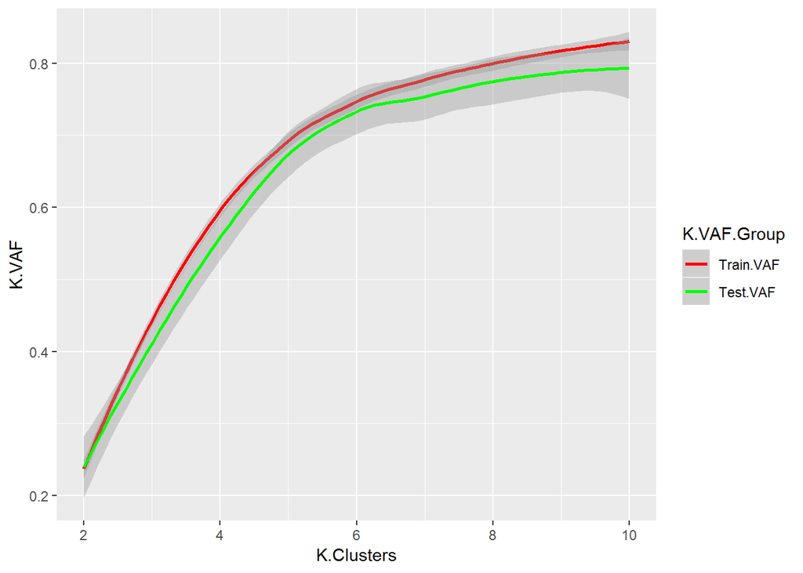

```r
ggplot(gm.results2) + geom_smooth(aes(x=K.Clusters,y=K.VAF, colour=K.VAF.Group)) + scale_colour_manual(values=c("red","green"))
```

The analysis below intends to aid in identifying the correct number of clusters between the range of four to six. Analyze Cluster groupings with pairs plot:

4 Clusters: In the 4 cluster pairs plot, Value savings in stocks shares a very strong correlation with the seperations of observations in blue throughout the data set. Gaurantor also shares a very strong correlation with the sepearations of observations of red accross the data set.

5 Clusters: In the 5 cluster pairs plot, the red and dark blue clusters seem to be very well defined for Value Savings Stocks. The red clusters also seem to be very well defined for credit.amount. There also seems to be very good sepeartion of clusters for light blue between Credit Amount and Guarontors.

6 Clusters: The seperation that was once there between Credit Amount and Value savings in Stocks has reverted, and there doesn’t seem to be any obvious inferences from the data concerning seperation of clusters.

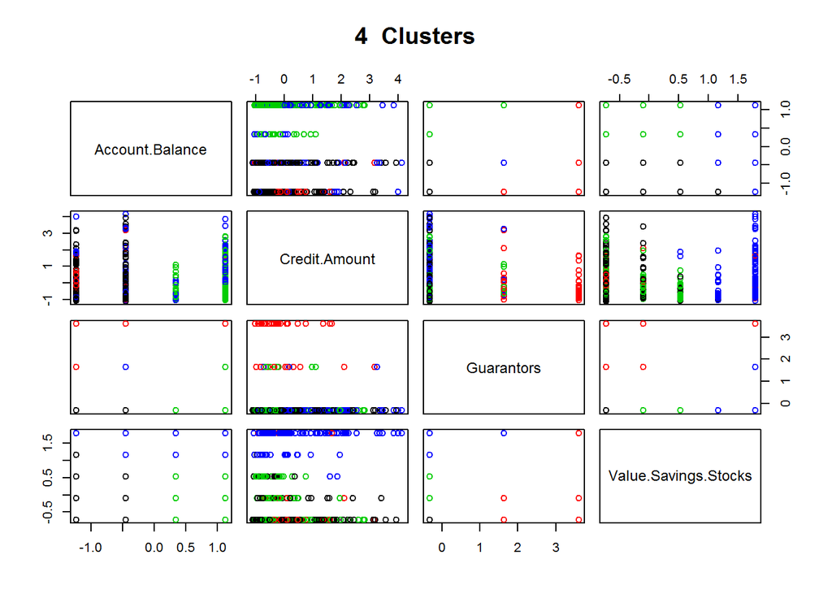

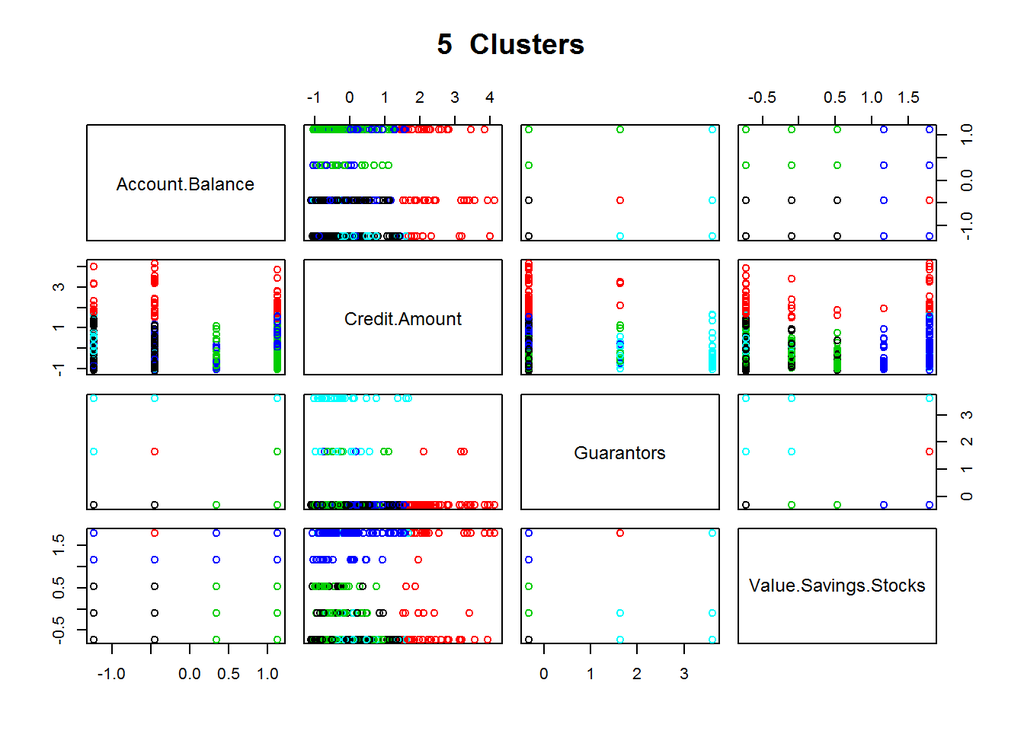

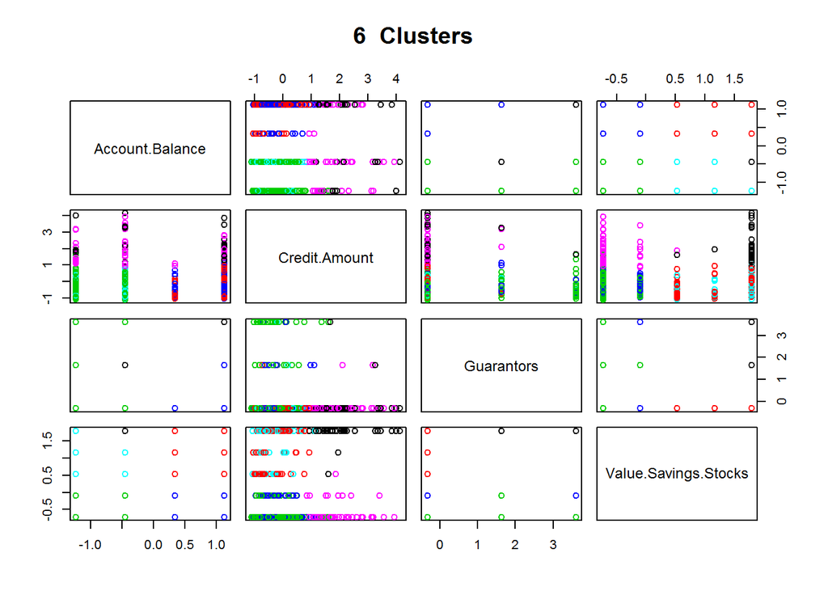

```r
k.test <- unlist(list())

for(x in 4:6){
  k.test[[x]] <- kmeans(german.credit.train, centers =x)
}


k.pairs <- list()
k.pairs <-
  for(x in 4:6){
    pairs(german.credit.train, col = k.test[[x]]$cluster, main =paste(x," Clusters"))
  }
```

Analyze Centers Before the centers can be analyzed, they had to be rescaled to their original values. Once that had been accomplished, six visualizations were created to analyze the centers. The first three place no bounds on the y axis, while the last three placed a limit between -10 and 10.

In the fourth visualization, four clusters are analyzed with a limited y-axis: There are three instances where the clusters have an absolute value above 2.5 from the 0 value axis. In the fifth visualization, five clusters are analyzed with a limited y-axis: There are six instances where the clusters have an absolute value above 2.5 from the 0 value axis. In the sixth visualization, six clusters are analyzed with a limited y-axis: There are nine instances where the clustershave an absolute value above 2.5 from the 0 value axis. .

What is the imporance of having clusters with values far from 0? The higher value that a specific cluster has for a given parameter, the more favorable the data within that cluster is towards that parameter. The lower the value is from a given parameter, the more likely that the data within that cluster will be unfavorable towards that parameter. When a cluster is measured to have 0 value for a given parameter, the cluster contains a population that is neither favorable nor unfavorable towards that parameter.

In summary, the five clusters seems to have the best deviations from 0 considering the benefit of keeping a miniminal count of clusters.

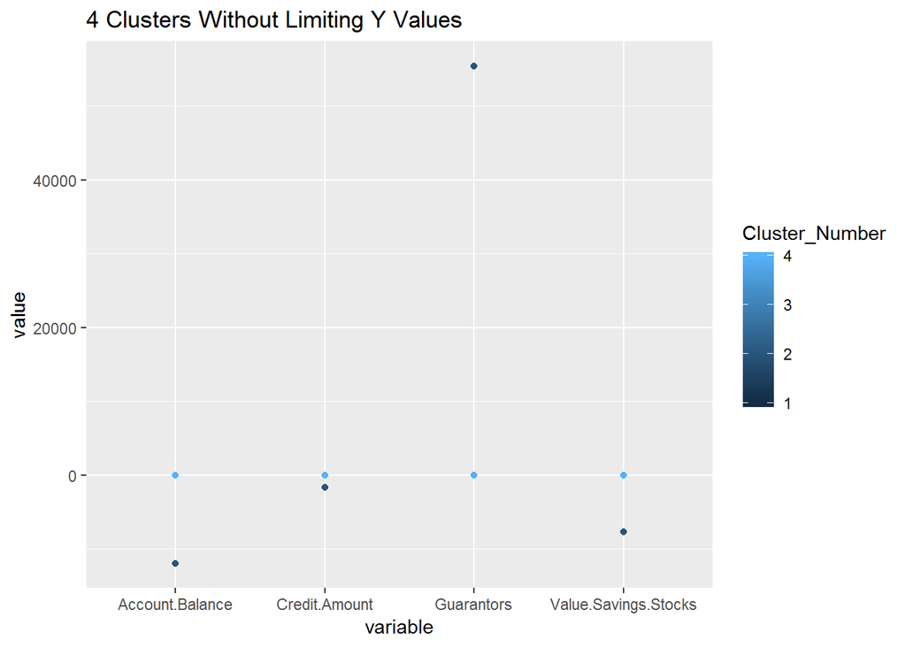

```r
rescale <- (apply(my.german.new,2,max)-apply(my.german.new,2,min)) + (apply(my.german.new,2,min))
k.4.centers.unscaled <- cbind(as.data.frame(((k.test[[4]]$centers)*rescale)),"Cluster Size" = c(rep("K4.Clusters",4)))
k.4.center.compare<-cbind(melt(k.4.centers.unscaled, id="Cluster Size"),Cluster_Number = rep(c(1,2,3,4),4))

k.5.centers.unscaled <- cbind(as.data.frame(((k.test[[5]]$centers)*rescale)),"Cluster Size" = c(rep("K5.Clusters",5)))
k.5.center.compare<-cbind(melt(k.5.centers.unscaled, id="Cluster Size"),Cluster_Number = rep(c(1,2,3,4,5),4))

k.6.centers.unscaled <- cbind(as.data.frame(((k.test[[6]]$centers)*rescale)),"Cluster Size" = c(rep("K6.Clusters",6)))
k.6.center.compare<-cbind(melt(k.6.centers.unscaled, id="Cluster Size"),Cluster_Number = rep(c(1,2,3,4,5,6),4))

ggplot(k.4.center.compare, aes(x=variable, y=value, colour=Cluster_Number))+geom_point() + ggtitle("4 Clusters Without Limiting Y Values")
```

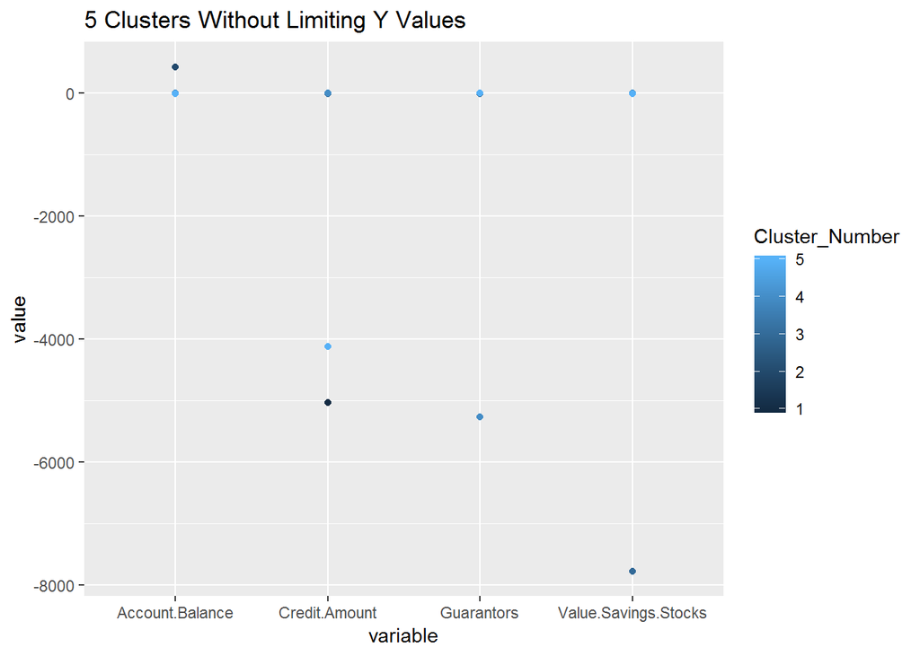

```r
ggplot(k.5.center.compare, aes(x=variable, y=value, colour=Cluster_Number))+geom_point() + ggtitle("5 Clusters Without Limiting Y Values")
```

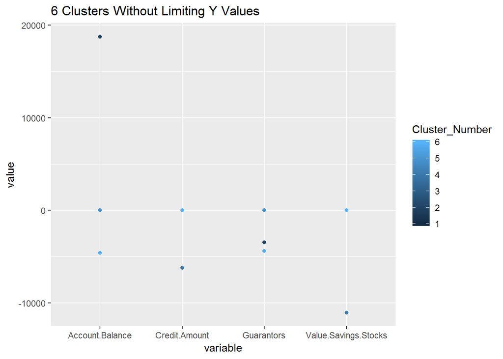

```r
ggplot(k.6.center.compare, aes(x=variable, y=value, colour=Cluster_Number))+geom_point() + ggtitle("6 Clusters Without Limiting Y Values")
```

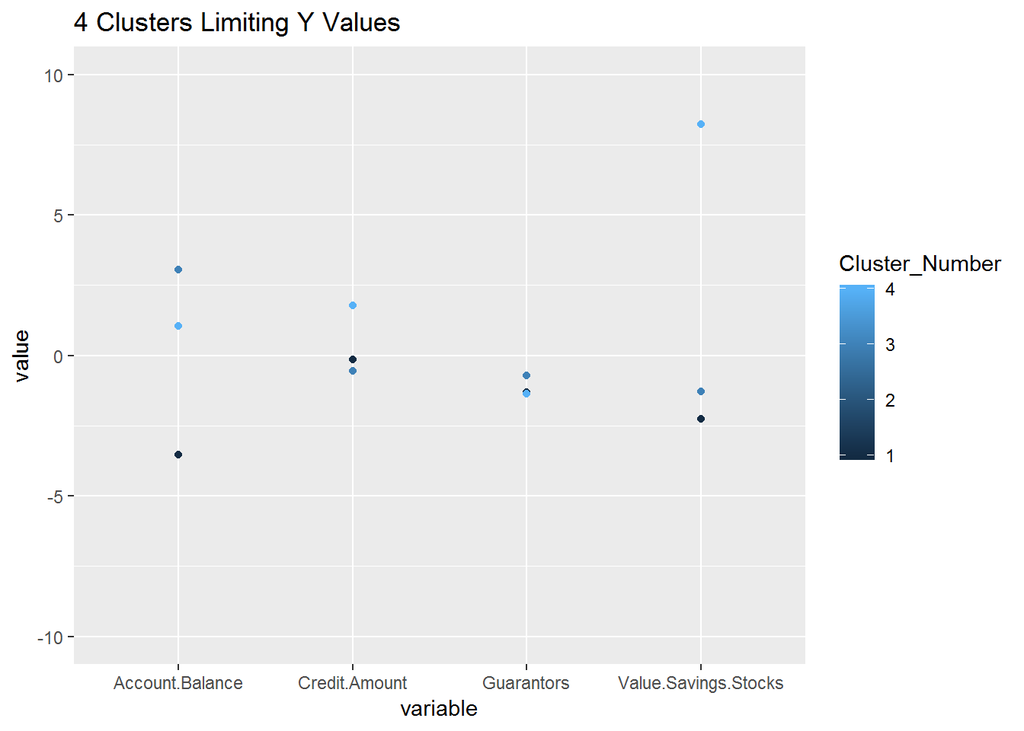

```r
ggplot(k.4.center.compare, aes(x=variable, y=value, colour=Cluster_Number))+geom_point() + ylim(-10,10) + ggtitle("4 Clusters Limiting Y Values")
```

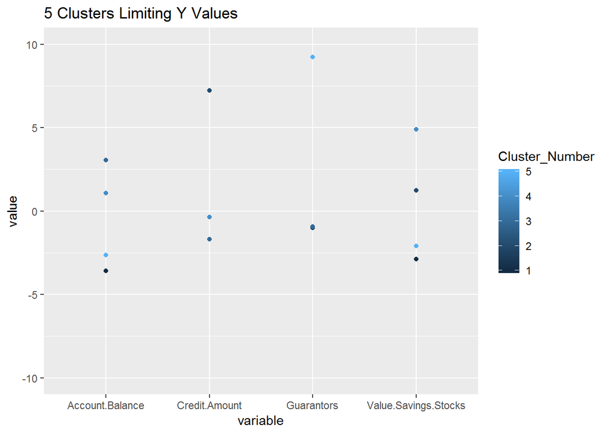

```r
ggplot(k.5.center.compare, aes(x=variable, y=value, colour=Cluster_Number))+geom_point() + ylim(-10,10) + ggtitle("5 Clusters Limiting Y Values")
```

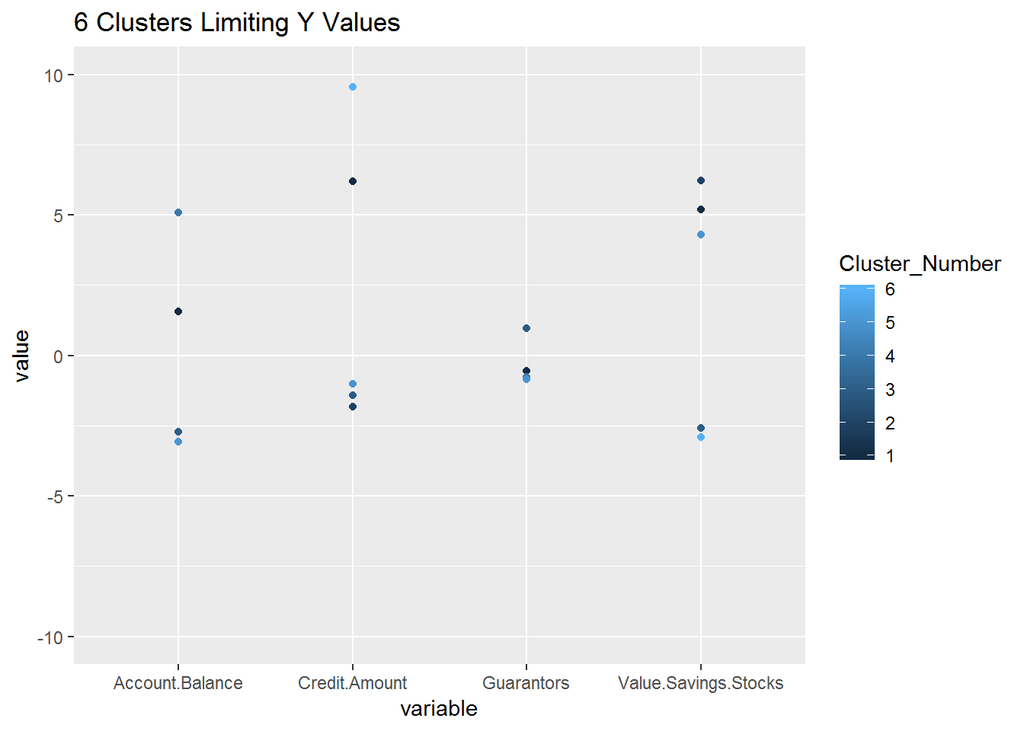

```r
ggplot(k.6.center.compare, aes(x=variable, y=value, colour=Cluster_Number))+geom_point() + ylim(-10,10) + ggtitle("6 Clusters Limiting Y Values")
```

Analyse cluster sizes Below are the cluster sizes shown by clusters = 4, clusters = 5, and clusters = 6.

```r
Cluster.Sizes <-
  for(x in 4:6){
  (print(k.test[[x]]$size))
}
```

```
## [1] 181  43 161 115
## [1] 164  47 150  98  41
## [1]  31  71 178 125  51  44
```

Analyze cluster standard deviations in size Below are the cluster deviations in size. This is slightly more interesting than the size of the clusters in that there is nearly no deviation in cluster sizes from 5 to 6 clusters while there is a deviation reduction in size of five when increasing cluster count from four to five.

```r
Cluster.size.sd <-for(x in 4:6){
  print(sd(k.test[[x]]$size))
}
```

```
## [1] 61.25357
## [1] 56.76707
## [1] 56.88819
```

6. Due to all the analysis previous to this, it was deemed that 5 clusters would be the most effective number of clusters. Below is the bivarioute plot of componenet 1 and component 2 showing the five clusters.

[figure not shown]

```r
km.gm.5 <- kmeans(german.credit.test, center = 5, nstart = 100)
km.gm.5$VAF <- km.gm.5$betweenss/km.gm.5$totss

clusplot(german.credit.train1, km.gm.5$cluster, color=TRUE, shade=TRUE,
    labels=2, lines=0)
```

7. Generate 3-5 komeans clusters.

```r
kom.num.of.clust <- 3:5
ko.gm.results <-
  lapply(kom.num.of.clust, function(x){
  komeans.german.results <- list()
  komeans.german.results$k <- x
  komeans.gm.train <- komeans(german.credit.train, nclust = x, lnorm=2, nloops=100)
  komeans.german.results$train.VAF <- komeans.gm.train$VAF
  #return(kmeans.german.result)
  return(list(x = komeans.german.results$k, Ko.Train.VAF = komeans.german.results$train.VAF))
  })
```

Komeans clustering analysis Below is the Scree plot for the komeans analysis for three to five clusters.

```r
ko.gm.results2 <- data.frame(matrix(unlist(ko.gm.results), nrow=3, byrow=T))
colnames(ko.gm.results2) <- c("KO.Clusters","KO.VAF.Group")
cbind(ko.gm.results2,gm.results2[2:4,-2])
```

```
##   KO.Clusters KO.VAF.Group K.Clusters     K.VAF
## 2           3    0.5135443          3 0.4450012
## 3           4    0.7047748          4 0.5941924
## 4           5    0.8598131          5 0.6971597
```

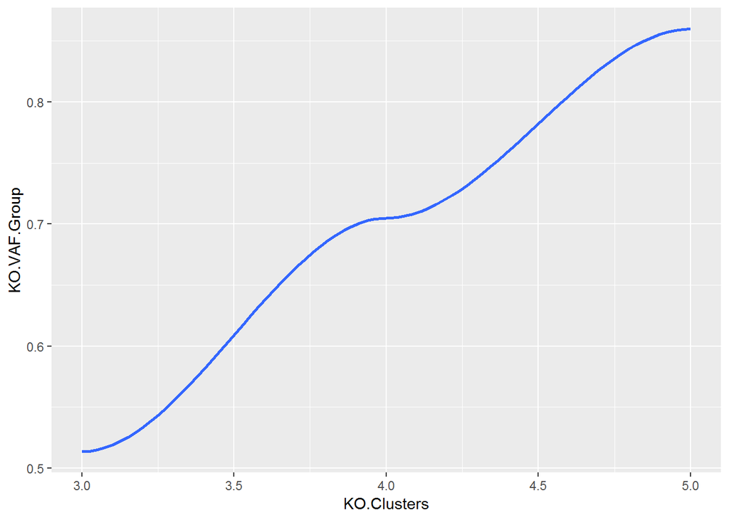

```r
ggplot(ko.gm.results2,(aes(x=KO.Clusters,y=KO.VAF.Group))) +geom_smooth()
```

8)Compare the chosen k-means solution with a komeans solution from an interpretablity perspective:

Comparisons of VAF. It was decided to utilize 5 clusters with the initial analysis utilziing Kmeans to explain a VAF of 70%. When the analysis is completed utilizing Komeans, four clusters explain 70% of the data, while five clusters explain 86% of the data. The five cluster solution found through kmeans will be compared to the five clusters found through komeans.

```r
kom.gm.5 <- komeans(german.credit.test1, nclust = 5, lnorm=2, nloops=100)
```

```r
k.vs.ko<- table(km.gm.5$cluster,kom.gm.5$Group) #This shows us how many are in each clusters
apply(k.vs.ko,2,sum)
```

```
##   0   2   4   6   8  10  12  16  17  18  19  20  21  22  23  24  25  26  27  28  29  31
##  11   6  44   6   7   2   8  29 151   8  40  59  85  12   9   2   8   1   2   2   6   2
```

```r
ko.new.data <- (which(kom.gm.5$Group %in% c(5,1,8,13,9)))
rescaled.ko.gm<-as.data.frame(kom.gm.5$data*rescale)[ko.new.data,]
ko.new.centers <- apply(rescaled.ko.gm,2,mean)
ko.new.centers
```

```
##      Account.Balance        Credit.Amount           Guarantors Value.Savings.Stocks
##            10533.286         15419146.714            13167.857             7898.857
```

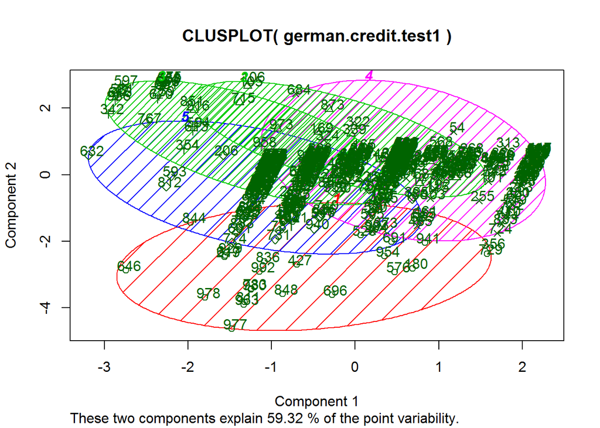

```r
ko.new.centers1 <- scale(german.credit.test1,
  center = ko.new.centers,
  scale = apply(rescaled.ko.gm,2,sd))
ko.new.centers2 <- kmeans(ko.new.centers1, centers=5, nstart = 100)
ko.new.centers2$VAF <- ko.new.centers2$betweenss/ko.new.centers2$totss
clusplot(german.credit.test1, ko.new.centers2$cluster, color=TRUE, shade=TRUE,
    labels=2, lines=0)
```

9) Summarize results and interpret the clusters/segments you choose as your final solution:

The VAF of Kmeans utilizing centers found through Komeans is compared to the VAF of centers found through the kmeans of the training data. There is an increase in variance explained by 5% by utilizing the centers found through Komeans over the method utilizing strictly kmeans.

```r
c("Using centers found from Komeans"= ko.new.centers2$VAF, "Using centers from training set of Kmeans"= km.gm.5$VAF)
```

```
##          Using centers found from Komeans Using centers from training set of Kmeans
##                                 0.7649781                                 0.7173950
```

10. You are given the task of recruitng 30 people (per segment) into these segments for focus groups and other follow-up A&U (attitudinal and Usage studies).

Q: a) What approach will you take to recruit people over the telephone? A: I would utilize a local phone book and randomly select people out of that phonebook. I would firs task them if they were willing to participate in the study, and if I found that they were open to the idea, I would begin to questions which would allow me to identify which segment they bleong to.

Q: b) Assume consumers who are recruited will be reimbursed for either coming to a focus group or for AUU surveys. Which of the consumers will you try to recruit? A: At the end of the day, the consumers must be selected randomly from a diverse population so that there is no biased data.

Q: c) How will you identify if a new recruit belongs to a partiuclare segment. A: The recruit should have most of the knowledge on hand in order to segment the recruit to a partiucalr group. If there is some data that the recruit doesn’t know about, the team should work with the recruit to try and obtain that data. If the process of obtaining that data will cost too many resources, the recruit can simply be droopped, and a new random recruit can replace them.